# Studies on The Impact of Economy Recession on stock prices

Elizabeth Peiwen Li

Project Goal:

Part 1 Extract Data from public sources: Yahoo Finance.

We chose 4 indexes, which are: Standard Poor 500, Dow Jones' Index, 10 Years Treasury Note Yield Index and Nasdaq Composite. And we chose 4 representative public companies in the U.S. , and they are: GOOG(Alphabet: Google);AIG (American International Group); XOM(Exxon Mobil Corporation); UAL(United Airline). Then we chose four counterpart Chinese companies which went public in the U.S., and they are: PTR(petrochina company limited); BIDU(baidu); CEA(china eastern airlines); LFC (China life insurance company limited)

Part 2: Study the impact of economy recession to the prices of the chosen indices and stock prices.

1. Study the impact of economy recession on the price of chosen stock market indices and chosen both U.S. public companies and Chinese companies listed in the U.S. for the past 40 years.
2. Study the impact of economy recession on the price change percentage of chosen stock market indices and chosen both U.S. public companies and Chinese companies listed in the U.S. for the past 40 years.

Note: The economy resession happened in the past 40 years are: Jan. 1980 - Jul. 1980; Jul. 1981 - Nov. 1982; Jul.1990 - Mar.1991; Mar. 2001 - Nov. 2001; Dec. 2007 - Jun. 2009.

Part 3: Choose one of the stock market index to conduct descriptive analysis and predictive analysis.

1. Decribe the dataset;
2. Study the distribution of the dataset;
3. Conduct the decriptive analysis.
4. Conduct the predictive analysis.

```python
import pandas as pd
import numpy as np
import matplotlib
import matplotlib.pyplot as plt
import seaborn as sns
from datetime import datetime
# from yahoo_finance import Share
import yfinance as yf
# from yahoofinancials import YahooFinancials
from pandas.plotting import register_matplotlib_converters
register_matplotlib_converters()
from bokeh.io import output_notebook
from bokeh.plotting import figure, show
from bokeh.models import Title
from bokeh.models import BoxAnnotation
from bokeh.models import Legend

output_notebook()
%matplotlib notebook
```

# Part 1: Data Extraction and Cleanning

```python
# download historical monthly stock price data of the 4 indices and 8 companies  from Yahoo Finance

index_data = ["^GSPC", "^DJI", "^TNX", "^IXIC"]
usa_inc_data = ["GOOG", "AIG", "XOM", "UAL"]
chn_inc_data = ["PTR", "BIDU", "CEA", "LFC"]


start = datetime(1979,1,1)
end = datetime(2019,1,1)

df_index_SPY = yf.download(index_data[0], start = start, end = end, interval = "1mo")
df_index_Dow = yf.download(index_data[1], start = start, end = end, interval = "1mo")
df_index_TNX = yf.download(index_data[2], start = start, end = end, interval = "1mo")
df_index_IXIC = yf.download(index_data[3], start = start, end = end, interval = "1mo")


df_usa_inc_GOOG = yf.download(usa_inc_data[0], start = start, end = end, interval = "1mo")
df_usa_inc_AIG = yf.download(usa_inc_data[1], start = start, end = end, interval = "1mo")
df_usa_inc_XOM = yf.download(usa_inc_data[2], start = start, end = end, interval = "1mo")
df_usa_inc_UAL = yf.download(usa_inc_data[3], start = start, end = end, interval = "1mo")


df_chn_inc_PTR = yf.download(chn_inc_data[0], start = start, end = end, interval = "1mo")
df_chn_inc_BIDU = yf.download(chn_inc_data[1], start = start, end = end, interval = "1mo")
df_chn_inc_CEA = yf.download(chn_inc_data[2], start = start, end = end, interval = "1mo")
df_chn_inc_LFC = yf.download(chn_inc_data[3], start = start, end = end, interval = "1mo")
```

```
[*********************100%***********************]  1 of 1 completed
[*********************100%***********************]  1 of 1 completed
[*********************100%***********************]  1 of 1 completed
[*********************100%***********************]  1 of 1 completed
[*********************100%***********************]  1 of 1 completed
[*********************100%***********************]  1 of 1 completed
[*********************100%***********************]  1 of 1 completed
[*********************100%***********************]  1 of 1 completed
[*********************100%***********************]  1 of 1 completed
[*********************100%***********************]  1 of 1 completed
[*********************100%***********************]  1 of 1 completed
[*********************100%***********************]  1 of 1 completed
```

```python
# Let's see what the dataset downloaded might look like
df_index_SPY.head()
```

| Date | Open | High | Low | Close | Adj Close | Volume |
| --- | --- | --- | --- | --- | --- | --- |
| 1979-01-01 | 96.110001 | 102.589996 | 95.220001 | 99.930000 | 99.930000 | 615730000 |
| 1979-02-01 | 99.930000 | 100.519997 | 95.379997 | 96.279999 | 96.279999 | 475710000 |
| 1979-03-01 | 96.279999 | 103.309998 | 95.980003 | 101.589996 | 101.589996 | 649800000 |
| 1979-04-01 | 101.559998 | 103.949997 | 100.139999 | 101.760002 | 101.760002 | 620650000 |
| 1979-05-01 | 101.760002 | 102.570000 | 97.489998 | 99.080002 | 99.080002 | 623740000 |

```python
df_index_SPY.tail()
```

| Date | Open | High | Low | Close | Adj Close | Volume |
| --- | --- | --- | --- | --- | --- | --- |
| 2018-08-01 | 2821.169922 | 2916.500000 | 2796.340088 | 2901.520020 | 2901.520020 | 69238220000 |
| 2018-09-01 | 2896.959961 | 2940.909912 | 2864.120117 | 2913.979980 | 2913.979980 | 62492080000 |
| 2018-10-01 | 2926.290039 | 2939.860107 | 2603.540039 | 2711.739990 | 2711.739990 | 91327930000 |
| 2018-11-01 | 2717.580078 | 2815.149902 | 2631.090088 | 2760.169922 | 2760.169922 | 80080110000 |
| 2018-12-01 | 2790.500000 | 2800.179932 | 2346.580078 | 2506.850098 | 2506.850098 | 83522570000 |

```python
df_index_SPY.dtypes
```

```
Open         float64
High         float64
Low          float64
Close        float64
Adj Close    float64
Volume         int64
dtype: object
```

```python
df_index_SPY.shape
```

```
(480, 6)
```

```python
df_index_SPY.dtypes
```

```
Open         float64
High         float64
Low          float64
Close        float64
Adj Close    float64
Volume         int64
dtype: object
```

```python
df_index_Dow.head()
```

| Date | Open | High | Low | Close | Adj Close | Volume |
| --- | --- | --- | --- | --- | --- | --- |
| 1985-01-01 | 1277.719971 | 1305.099976 | 1266.890015 | 1286.770020 | 1286.770020 | 44450000 |
| 1985-02-01 | 1276.939941 | 1307.530029 | 1263.910034 | 1284.010010 | 1284.010010 | 207300000 |
| 1985-03-01 | 1285.339966 | 1309.959961 | 1242.819946 | 1266.780029 | 1266.780029 | 201050000 |
| 1985-04-01 | 1264.800049 | 1290.300049 | 1245.800049 | 1258.060059 | 1258.060059 | 187110000 |
| 1985-05-01 | 1257.180054 | 1320.790039 | 1235.530029 | 1315.410034 | 1315.410034 | 242250000 |

```python
df_index_Dow.tail()
```

| Date | Open | High | Low | Close | Adj Close | Volume |
| --- | --- | --- | --- | --- | --- | --- |
| 2018-08-01 | 25461.630859 | 26167.939453 | 24965.769531 | 25964.820312 | 25964.820312 | 5635410000 |
| 2018-09-01 | 25916.070312 | 26769.160156 | 25754.320312 | 26458.310547 | 26458.310547 | 5262500000 |
| 2018-10-01 | 26598.359375 | 26951.810547 | 24122.230469 | 25115.759766 | 25115.759766 | 8373350000 |
| 2018-11-01 | 25142.080078 | 26277.820312 | 24268.740234 | 25538.460938 | 25538.460938 | 7226940000 |
| 2018-12-01 | 25779.570312 | 25980.210938 | 21712.529297 | 23327.460938 | 23327.460938 | 8101540000 |

```python
df_index_Dow.shape
```

```
(408, 6)
```

```python
df_index_Dow.dtypes
```

```
Open         float64
High         float64
Low          float64
Close        float64
Adj Close    float64
Volume         int64
dtype: object
```

```python
df_usa_inc_GOOG.head()
```

| Date | Open | High | Low | Close | Adj Close | Volume |
| --- | --- | --- | --- | --- | --- | --- |
| 2004-08-01 | 49.813286 | 56.528118 | 47.800831 | 50.993862 | 50.993862 | 134241100.0 |
| 2004-09-01 | 51.158245 | 67.257904 | 49.285267 | 64.558022 | 64.558022 | 213503200.0 |
| 2004-10-01 | 65.155777 | 99.601669 | 64.209328 | 94.964050 | 94.964050 | 516060900.0 |
| 2004-11-01 | 96.413620 | 100.423584 | 80.353813 | 90.650223 | 90.650223 | 557267200.0 |
| 2004-12-01 | 90.635277 | 99.566803 | 83.920448 | 96.035034 | 96.035034 | 291772100.0 |

```python
df_usa_inc_GOOG.tail()
```

| Date | Open | High | Low | Close | Adj Close | Volume |
| --- | --- | --- | --- | --- | --- | --- |
| 2018-08-01 | 1228.000000 | 1256.500000 | 1188.239990 | 1218.189941 | 1218.189941 | 28808400.0 |
| 2018-09-01 | 1204.270020 | 1212.989990 | 1146.910034 | 1193.469971 | 1193.469971 | 28862400.0 |
| 2018-10-01 | 1199.890015 | 1209.959961 | 995.830017 | 1076.770020 | 1076.770020 | 48494700.0 |
| 2018-11-01 | 1075.800049 | 1095.569946 | 996.020020 | 1094.430054 | 1094.430054 | 36735100.0 |
| 2018-12-01 | 1123.140015 | 1124.650024 | 970.109985 | 1035.609985 | 1035.609985 | 40257600.0 |

```python
df_usa_inc_GOOG.shape
```

```
(175, 6)
```

```python
df_usa_inc_GOOG.dtypes
```

```
Open         float64
High         float64
Low          float64
Close        float64
Adj Close    float64
Volume       float64
dtype: object
```

We chose to observe 3 representative datasets(2 index and 1 company), and learnt that, 1) all the dataset downloaded have the same columns: date; open price, highest price, lowest price, close price, adj close price and transaction volume. 2) Although we chose to download the monthly data from Jan. 1 1979 to Jan.1 2019, however, not all the indices or company have the data from Jan. 1 1979. For example, Google went public on August 19 2004, so the stock price data started from Aug. 2004. Therefore, for the analysis purposes, we might need clean or rearrange the dataset later.

```python
# Clean the dataset, drop the rows with missing values first.
df_index_SPY = df_index_SPY.dropna()
df_index_Dow = df_index_Dow.dropna()
df_index_TNX = df_index_TNX.dropna()
df_index_IXIC = df_index_IXIC.dropna()


df_usa_inc_GOOG = df_usa_inc_GOOG.dropna()
df_usa_inc_AIG = df_usa_inc_AIG.dropna()
df_usa_inc_XOM = df_usa_inc_XOM.dropna()
df_usa_inc_UAL = df_usa_inc_UAL.dropna()


df_chn_inc_PTR = df_chn_inc_PTR.dropna()
df_chn_inc_BIDU = df_chn_inc_BIDU.dropna()
df_chn_inc_CEA = df_chn_inc_CEA.dropna()
df_chn_inc_LFC = df_chn_inc_LFC.dropna()
```

```python
# Clean the dataset, drop all the rows with zero values.
df_index_SPY  = df_index_SPY[~(df_index_SPY == 0).any(axis=1)]
df_index_Dow = df_index_Dow[~(df_index_Dow == 0).any(axis=1)]
df_index_TNX = df_index_TNX[~(df_index_TNX == 0).any(axis=1)]
df_index_IXIC = df_index_IXIC[~(df_index_IXIC == 0).any(axis=1)]

df_usa_inc_GOOG = df_usa_inc_GOOG[~(df_usa_inc_GOOG == 0).any(axis=1)]
df_usa_inc_AIG = df_usa_inc_AIG[~(df_usa_inc_AIG == 0).any(axis=1)]
df_usa_inc_XOM = df_usa_inc_XOM[~(df_usa_inc_XOM == 0).any(axis=1)]
df_usa_inc_UAL = df_usa_inc_UAL[~(df_usa_inc_UAL == 0).any(axis=1)]

df_chn_inc_PTR = df_chn_inc_PTR[~(df_chn_inc_PTR == 0).any(axis=1)]
df_chn_inc_BIDU = df_chn_inc_BIDU[~(df_chn_inc_BIDU == 0).any(axis=1)]
df_chn_inc_CEA = df_chn_inc_CEA[~(df_chn_inc_CEA == 0).any(axis=1)]
df_chn_inc_LFC = df_chn_inc_LFC[~(df_chn_inc_LFC == 0).any(axis=1)]
```

```python
# From previous study, we know that the date in all the dataframes are the index.
# Convert the index of the dataframe into a column
df_index_SPY = df_index_SPY.reset_index()
df_index_Dow = df_index_Dow.reset_index()
df_index_TNX = df_index_TNX.reset_index()
df_index_IXIC = df_index_IXIC.reset_index()


df_usa_inc_GOOG = df_usa_inc_GOOG.reset_index()
df_usa_inc_AIG = df_usa_inc_AIG.reset_index()
df_usa_inc_XOM = df_usa_inc_XOM.reset_index()
df_usa_inc_UAL = df_usa_inc_UAL.reset_index()


df_chn_inc_PTR = df_chn_inc_PTR.reset_index()
df_chn_inc_BIDU = df_chn_inc_BIDU.reset_index()
df_chn_inc_CEA = df_chn_inc_CEA.reset_index()
df_chn_inc_LFC = df_chn_inc_LFC.reset_index()
```

# Part 2: Study the impact of economy recession to the prices of the chosen indices and stock prices.

```python
# Plot the widely used indexes with Bokeh;
p = figure(plot_width = 950, plot_height = 500, x_axis_type = "datetime")

p.line(df_index_SPY.Date, df_index_SPY['Close'], legend = 'Standard Poor 500 Index',
       alpha = 0.7,  muted_alpha=0.1, line_color = "navy", line_width = 2)
p.line(df_index_Dow.Date, df_index_Dow['Close'], legend = 'Dow Johns Industry Average Index',
       alpha = 0.7,  muted_alpha=0.1, line_color = "firebrick", line_width = 2)
p.line(df_index_TNX.Date, df_index_TNX['Close'], legend = '10 Years Treasury Note Yield Index',
       alpha = 0.7,  muted_alpha=0.1, line_color = "green", line_width = 2)
p.line(df_index_IXIC.Date, df_index_IXIC['Close'], legend = 'Nasdaq Composite',
       alpha = 0.7,  muted_alpha=0.1, line_color = "orange", line_width = 2)

#shade the area with recession during the past 40 years.
box1 = BoxAnnotation(left = datetime(1980,1,1), right = datetime(1980,7,1), fill_alpha = 0.5, fill_color = "grey")
box2 = BoxAnnotation(left = datetime(1981,7,1), right = datetime(1982,11,1), fill_alpha = 0.5, fill_color = "grey")
box3 = BoxAnnotation(left = datetime(1990,7,1), right = datetime(1991,3,1), fill_alpha = 0.5, fill_color = "grey")
box4 = BoxAnnotation(left = datetime(2001,3,1), right = datetime(2001,11,1), fill_alpha = 0.5, fill_color = "grey")
box5 = BoxAnnotation(left = datetime(2007,12,1), right = datetime(2009,6,1), fill_alpha = 0.5, fill_color = "grey")

# hide the line plot by clicking the legend
p.legend.location = "top_left"
p.legend.click_policy = "mute"
p.xaxis.axis_label = "year"
p.yaxis.axis_label = "price"

p.add_layout(box1)
p.add_layout(box2)
p.add_layout(box3)
p.add_layout(box4)
p.add_layout(box5)
show(p)
```

[interactive chart not shown]

```python
# Plot the close price of chosen American public companies with Bokeh;
p = figure(plot_width = 950, plot_height = 500, x_axis_type = "datetime")

p.line(df_usa_inc_GOOG.Date, df_usa_inc_GOOG['Close'], legend = 'Monthly stock price of Google',
       alpha = 0.7,  muted_alpha=0.1, line_color = "navy", line_width = 2)
p.line(df_usa_inc_AIG.Date, df_usa_inc_AIG['Close'], legend = 'Monthly stock price of American International Group',
       alpha = 0.7,  muted_alpha=0.1, line_color = "firebrick", line_width = 2)
p.line(df_usa_inc_XOM.Date, df_usa_inc_XOM['Close'], legend = 'Monthly stock price of Exxon Mobil Corporation',
       alpha = 0.7,  muted_alpha=0.1, line_color = "green", line_width = 2)
p.line(df_usa_inc_UAL.Date, df_usa_inc_UAL['Close'], legend = 'Monthly stock price of Unitied Airlines',
       alpha = 0.7,  muted_alpha=0.1, line_color = "orange", line_width = 2)

#shade the area with recession during the past 40 years.
box1 = BoxAnnotation(left = datetime(1980,1,1), right = datetime(1980,7,1), fill_alpha = 0.5, fill_color = "grey")
box2 = BoxAnnotation(left = datetime(1981,7,1), right = datetime(1982,11,1), fill_alpha = 0.5, fill_color = "grey")
box3 = BoxAnnotation(left = datetime(1990,7,1), right = datetime(1991,3,1), fill_alpha = 0.5, fill_color = "grey")
box4 = BoxAnnotation(left = datetime(2001,3,1), right = datetime(2001,11,1), fill_alpha = 0.5, fill_color = "grey")
box5 = BoxAnnotation(left = datetime(2007,12,1), right = datetime(2009,6,1), fill_alpha = 0.5, fill_color = "grey")

# hide the line plot by clicking the legend
p.legend.location = "top_left"
p.legend.click_policy = "mute"
p.xaxis.axis_label = "year"
p.yaxis.axis_label = "price"

p.add_layout(box1)
p.add_layout(box2)
p.add_layout(box3)
p.add_layout(box4)
p.add_layout(box5)
show(p)
```

[interactive chart not shown]

```python
# Plot the close price of chosen Chinese public companies with Bokeh;
p = figure(plot_width = 950, plot_height = 500, x_axis_type = "datetime")

p.line(df_chn_inc_PTR.Date, df_chn_inc_PTR['Close'], legend = 'Monthly stock price of China Petro',
       alpha = 0.7,  muted_alpha=0.1, line_color = "navy", line_width = 2)
p.line(df_chn_inc_BIDU.Date, df_chn_inc_BIDU['Close'], legend = 'Monthly stock price of Baidu',
       alpha = 0.7,  muted_alpha=0.1, line_color = "firebrick", line_width = 2)
p.line(df_chn_inc_CEA.Date, df_chn_inc_CEA['Close'], legend = 'Monthly stock price of China Eastern Airline',
       alpha = 0.7,  muted_alpha=0.1, line_color = "green", line_width = 2)
p.line(df_chn_inc_LFC.Date, df_chn_inc_LFC['Close'], legend = 'Monthly stock price of China Life Insurance',
       alpha = 0.7,  muted_alpha=0.1, line_color = "orange", line_width = 2)

#shade the area with recession during the past 40 years.
box1 = BoxAnnotation(left = datetime(1980,1,1), right = datetime(1980,7,1), fill_alpha = 0.5, fill_color = "grey")
box2 = BoxAnnotation(left = datetime(1981,7,1), right = datetime(1982,11,1), fill_alpha = 0.5, fill_color = "grey")
box3 = BoxAnnotation(left = datetime(1990,7,1), right = datetime(1991,3,1), fill_alpha = 0.5, fill_color = "grey")
box4 = BoxAnnotation(left = datetime(2001,3,1), right = datetime(2001,11,1), fill_alpha = 0.5, fill_color = "grey")
box5 = BoxAnnotation(left = datetime(2007,12,1), right = datetime(2009,6,1), fill_alpha = 0.5, fill_color = "grey")

# hide the line plot by clicking the legend
p.legend.location = "top_left"
p.legend.click_policy = "mute"
p.xaxis.axis_label = "year"
p.yaxis.axis_label = "price"

p.add_layout(box1)
p.add_layout(box2)
p.add_layout(box3)
p.add_layout(box4)
p.add_layout(box5)
show(p)
```

[interactive chart not shown]

From the above data visualization of prices of chosen stock market index and stock prices, we can learn that:1) the economic ressession did affect the stock market inddex and each stock we chosen here. 2) Among the five economic ressession happened during the past 40 years, we can see that 2008 global finance crisis had the most negative influences in the stock market, especially for the American International Group. The price almost hit the bottom. It reminded me the U.S. government used 182 billion dollars to bail it out from bankruptcy. 3) Compared with the traditional giants like energy, airline or insurance finance companies, the high tech company has a tremendous growth rate. 4)For Chinese companies listed in the U.S. stock market, it shared the similar pattern with the U.S. counterpart, meaning the market is fair. If one industry is booming, both stock prices of U.S. companies and Chinese companies in that industry are likely to grow.

```python
# Add a new column named Price Change in the dataset
df_index_cc_SPY = pd.DataFrame(df_index_SPY)
df_index_cc_SPY['Price Change Pct'] = df_index_cc_SPY.apply(lambda row: (row.Close -
                                  row.Open)/row.Open, axis = 1)
df_index_cc_SPY.head()
```

|  | Date | Open | High | Low | Close | Adj Close | Volume | Price Change Pct |
| --- | --- | --- | --- | --- | --- | --- | --- | --- |
| 0 | 1979-01-01 | 96.110001 | 102.589996 | 95.220001 | 99.930000 | 99.930000 | 615730000 | 0.039746 |
| 1 | 1979-02-01 | 99.930000 | 100.519997 | 95.379997 | 96.279999 | 96.279999 | 475710000 | -0.036526 |
| 2 | 1979-03-01 | 96.279999 | 103.309998 | 95.980003 | 101.589996 | 101.589996 | 649800000 | 0.055152 |
| 3 | 1979-04-01 | 101.559998 | 103.949997 | 100.139999 | 101.760002 | 101.760002 | 620650000 | 0.001969 |
| 4 | 1979-05-01 | 101.760002 | 102.570000 | 97.489998 | 99.080002 | 99.080002 | 623740000 | -0.026336 |

```python
# Repeat the same process for all other dataset
df_index_cc_Dow = pd.DataFrame(df_index_Dow)
df_index_cc_Dow['Price Change Pct'] = df_index_cc_Dow.apply(lambda row: (row.Close -
                                  row.Open)/row.Open, axis = 1)
df_index_cc_TNX = pd.DataFrame(df_index_TNX)
df_index_cc_TNX['Price Change Pct'] = df_index_cc_TNX.apply(lambda row: (row.Close -
                                  row.Open)/row.Open, axis = 1)
df_index_cc_IXIC = pd.DataFrame(df_index_IXIC)
df_index_cc_IXIC['Price Change Pct'] = df_index_cc_IXIC.apply(lambda row: (row.Close -
                                  row.Open)/row.Open, axis = 1)

df_index_cc_GOOG = pd.DataFrame(df_usa_inc_GOOG)
df_index_cc_GOOG['Price Change Pct'] = df_index_cc_GOOG.apply(lambda row: (row.Close -
                                  row.Open)/row.Open, axis = 1)
df_index_cc_AIG = pd.DataFrame(df_usa_inc_AIG)
df_index_cc_AIG['Price Change Pct'] = df_index_cc_AIG.apply(lambda row: (row.Close -
                                  row.Open)/row.Open, axis = 1)
df_index_cc_XOM = pd.DataFrame(df_usa_inc_XOM)
df_index_cc_XOM['Price Change Pct'] = df_index_cc_XOM.apply(lambda row: (row.Close -
                                  row.Open)/row.Open, axis = 1)
df_index_cc_UAL = pd.DataFrame(df_usa_inc_UAL)
df_index_cc_UAL['Price Change Pct'] = df_index_cc_UAL.apply(lambda row: (row.Close -
                                  row.Open)/row.Open, axis = 1)

df_index_cc_PTR = pd.DataFrame(df_chn_inc_PTR)
df_index_cc_PTR['Price Change Pct'] = df_index_cc_PTR.apply(lambda row: (row.Close -
                                  row.Open)/row.Open, axis = 1)
df_index_cc_BIDU = pd.DataFrame(df_chn_inc_BIDU)
df_index_cc_BIDU['Price Change Pct'] = df_index_cc_BIDU.apply(lambda row: (row.Close -
                                  row.Open)/row.Open, axis = 1)
df_index_cc_CEA = pd.DataFrame(df_chn_inc_CEA)
df_index_cc_CEA['Price Change Pct'] = df_index_cc_CEA.apply(lambda row: (row.Close -
                                  row.Open)/row.Open, axis = 1)
df_index_cc_LFC = pd.DataFrame(df_chn_inc_LFC)
df_index_cc_LFC['Price Change Pct'] = df_index_cc_LFC.apply(lambda row: (row.Close -
                                  row.Open)/row.Open, axis = 1)
```

```python
# Plot and compare the price change among the indexes with Bokeh:
p = figure(plot_width = 950, plot_height = 500, x_axis_type = "datetime")

p.line(df_index_cc_SPY.Date, df_index_cc_SPY['Price Change Pct'], legend = 'Standard Poor 500 Index Monthly Price Change Percentage',
       alpha = 0.7,  muted_alpha=0.1, line_color = "navy", line_width = 2)
p.line(df_index_cc_Dow.Date, df_index_cc_Dow['Price Change Pct'], legend = 'Dow Johns Industry Average Index Monthly Price Change Percentage',
       alpha = 0.7,  muted_alpha=0.1, line_color = "firebrick", line_width = 2)
p.line(df_index_cc_TNX.Date,df_index_cc_TNX['Price Change Pct'], legend = '10 Years Treasury Note Yield Index Monthly Price Change Percentage',
       alpha = 0.7,  muted_alpha=0.1, line_color = "green", line_width = 2)
p.line(df_index_cc_IXIC.Date,df_index_cc_IXIC['Price Change Pct'], legend= 'Nasdaq Composite Monthly Price Change Percentage',
       alpha = 0.7,  muted_alpha=0.1, line_color = "orange", line_width = 2)

#shade the area with recession during the past 40 years.
box1 = BoxAnnotation(left = datetime(1980,1,1), right = datetime(1980,7,1), fill_alpha = 0.5, fill_color = "grey")
box2 = BoxAnnotation(left = datetime(1981,7,1), right = datetime(1982,11,1), fill_alpha = 0.5, fill_color = "grey")
box3 = BoxAnnotation(left = datetime(1990,7,1), right = datetime(1991,3,1), fill_alpha = 0.5, fill_color = "grey")
box4 = BoxAnnotation(left = datetime(2001,3,1), right = datetime(2001,11,1), fill_alpha = 0.5, fill_color = "grey")
box5 = BoxAnnotation(left = datetime(2007,12,1), right = datetime(2009,6,1), fill_alpha = 0.5, fill_color = "grey")

# hide the line plot by clicking the legend
p.legend.location = "top_left"
p.legend.click_policy = "mute"
p.xaxis.axis_label = "year"
p.yaxis.axis_label = "Price Change Percentage"

p.add_layout(box1)
p.add_layout(box2)
p.add_layout(box3)
p.add_layout(box4)
p.add_layout(box5)
show(p)
```

[interactive chart not shown]

```python
# Plot and compare the price change among the chose American stocks with Bokeh:
p = figure(plot_width = 950, plot_height = 500, x_axis_type = "datetime")

p.line(df_index_cc_GOOG.Date, df_index_cc_GOOG['Price Change Pct'], legend = 'Google Monthly Stock Price Change',
       alpha = 0.7,  muted_alpha=0.1, line_color = "navy", line_width = 2)
p.line(df_index_cc_AIG.Date, df_index_cc_AIG['Price Change Pct'], legend = 'AIG Monthly Stock Price Change',
       alpha = 0.7,  muted_alpha=0.1, line_color = "firebrick", line_width = 2)
p.line(df_index_cc_XOM.Date,df_index_cc_XOM['Price Change Pct'], legend = 'Exxon Mobil Monthly Stock Price Change',
       alpha = 0.7,  muted_alpha=0.1, line_color = "green", line_width = 2)
p.line(df_index_cc_UAL.Date,df_index_cc_UAL['Price Change Pct'], legend = 'United Airline Monthly Stock Price Change',
       alpha = 0.7,  muted_alpha=0.1, line_color = "orange", line_width = 2)

#shade the area with recession during the past 40 years.
box1 = BoxAnnotation(left = datetime(1980,1,1), right = datetime(1980,7,1), fill_alpha = 0.5, fill_color = "grey")
box2 = BoxAnnotation(left = datetime(1981,7,1), right = datetime(1982,11,1), fill_alpha = 0.5, fill_color = "grey")
box3 = BoxAnnotation(left = datetime(1990,7,1), right = datetime(1991,3,1), fill_alpha = 0.5, fill_color = "grey")
box4 = BoxAnnotation(left = datetime(2001,3,1), right = datetime(2001,11,1), fill_alpha = 0.5, fill_color = "grey")
box5 = BoxAnnotation(left = datetime(2007,12,1), right = datetime(2009,6,1), fill_alpha = 0.5, fill_color = "grey")

# hide the line plot by clicking the legend
p.legend.location = "top_left"
p.legend.click_policy = "mute"
p.xaxis.axis_label = "year"
p.yaxis.axis_label = "Price Change Percentage"

p.add_layout(box1)
p.add_layout(box2)
p.add_layout(box3)
p.add_layout(box4)
p.add_layout(box5)
show(p)
```

[interactive chart not shown]

```python
# Plot and compare the price change among the chose Chinese stocks with Bokeh:
p = figure(plot_width = 950, plot_height = 500, x_axis_type = "datetime")

p.line(df_index_cc_PTR.Date, df_index_cc_PTR['Price Change Pct'], legend = 'China Petro Monthly Stock Price Change',
       alpha = 0.7,  muted_alpha=0.1, line_color = "navy", line_width = 2)
p.line(df_index_cc_BIDU.Date, df_index_cc_BIDU['Price Change Pct'], legend = 'Baidu Monthly Stock Price Change',
       alpha = 0.7,  muted_alpha=0.1, line_color = "firebrick", line_width = 2)
p.line(df_index_cc_CEA.Date,df_index_cc_CEA['Price Change Pct'], legend = 'China Eastern Airline Monthly Stock Price Change',
       alpha = 0.7,  muted_alpha=0.1, line_color = "green", line_width = 2)
p.line(df_index_cc_LFC.Date,df_index_cc_LFC['Price Change Pct'], legend = 'China Life Insurance Monthly Stock Price Change',
       alpha = 0.7,  muted_alpha=0.1, line_color = "orange", line_width = 2)

#shade the area with recession during the past 40 years.
box1 = BoxAnnotation(left = datetime(1980,1,1), right = datetime(1980,7,1), fill_alpha = 0.5, fill_color = "grey")
box2 = BoxAnnotation(left = datetime(1981,7,1), right = datetime(1982,11,1), fill_alpha = 0.5, fill_color = "grey")
box3 = BoxAnnotation(left = datetime(1990,7,1), right = datetime(1991,3,1), fill_alpha = 0.5, fill_color = "grey")
box4 = BoxAnnotation(left = datetime(2001,3,1), right = datetime(2001,11,1), fill_alpha = 0.5, fill_color = "grey")
box5 = BoxAnnotation(left = datetime(2007,12,1), right = datetime(2009,6,1), fill_alpha = 0.5, fill_color = "grey")

# hide the line plot by clicking the legend
p.legend.location = "top_left"
p.legend.click_policy = "mute"
p.xaxis.axis_label = "year"
p.yaxis.axis_label = "Price Change Percentage"

p.add_layout(box1)
p.add_layout(box2)
p.add_layout(box3)
p.add_layout(box4)
p.add_layout(box5)
show(p)
```

[interactive chart not shown]

From above data visualization of the price change percentage for the past 40 years, we find that:1) Compare with the major three stock market index (S&P 500, Dow and Nasdaq Composite), S&P 500 has been relatively stable than the other two. 2)From the 4 chose U.S. stocks, the energy company Exxon Mobil has been relatively stable. Over the past 40 years the insurance tycoon AIG has also been relatively stable, except during the time in 2008 finance crisis. Similarly, for Chinese companies, both the energy and insurance company China Petro and China Life Insurance have relatively stable stock prices compared with the other 2. Therefore, to choose a stock, if considering a long term investment, may consider the traditional industry such as energy and life insurance.

# Part 3: Choose one of the stock market index to conduct descriptive analysis and predictive analysis on stock prices.

First of all, as we can see from above analysis, the fluctuation of 10 years Treasury Note Yield Index has been in a relatively very small range. Therefore, we decide to not analyze the TNX dataset first.

Among all other three indices, Dow is a stock market index that measures the stock performance of 30 large companies listed on stock exchanges in the United States. Although it is one of the most commonly followed equity indices, since it only includes 30 companies and is not weighted by market capitalization and is not a weighted arithmetic mean.many investors consider the S&P 500 Index, which also includes the 30 components of the Dow, to be a better representation of the U.S. stock market.

In addition, The Nasdaq-100 is heavily allocated towards top performing industries such as Technology, Consumer Services, and Health Care. The traditional industry like utility only weighted 1%, and industrials only weighted 5%. However, the varieties and weighted propotion of industries in S&P 500 are more balanced.And here, 6 out 8 chosen stocks in this study are from traditional industries.

Therefore, among all four chosen stock market indices, we'll choose S&P 500 for further descriptive analysis and predictive analysis.

# Descriptive Analysis

```python
df_index_SPY.head()
```

|  | Date | Open | High | Low | Close | Adj Close | Volume | Price Change Pct |
| --- | --- | --- | --- | --- | --- | --- | --- | --- |
| 0 | 1979-01-01 | 96.110001 | 102.589996 | 95.220001 | 99.930000 | 99.930000 | 615730000 | 0.039746 |
| 1 | 1979-02-01 | 99.930000 | 100.519997 | 95.379997 | 96.279999 | 96.279999 | 475710000 | -0.036526 |
| 2 | 1979-03-01 | 96.279999 | 103.309998 | 95.980003 | 101.589996 | 101.589996 | 649800000 | 0.055152 |
| 3 | 1979-04-01 | 101.559998 | 103.949997 | 100.139999 | 101.760002 | 101.760002 | 620650000 | 0.001969 |
| 4 | 1979-05-01 | 101.760002 | 102.570000 | 97.489998 | 99.080002 | 99.080002 | 623740000 | -0.026336 |

```python
# Reset date into index
df_index_SPY.set_index('Date', inplace=True)
```

```python
df_index_SPY.head()
```

| Date | Open | High | Low | Close | Adj Close | Volume | Price Change Pct |
| --- | --- | --- | --- | --- | --- | --- | --- |
| 1979-01-01 | 96.110001 | 102.589996 | 95.220001 | 99.930000 | 99.930000 | 615730000 | 0.039746 |
| 1979-02-01 | 99.930000 | 100.519997 | 95.379997 | 96.279999 | 96.279999 | 475710000 | -0.036526 |
| 1979-03-01 | 96.279999 | 103.309998 | 95.980003 | 101.589996 | 101.589996 | 649800000 | 0.055152 |
| 1979-04-01 | 101.559998 | 103.949997 | 100.139999 | 101.760002 | 101.760002 | 620650000 | 0.001969 |
| 1979-05-01 | 101.760002 | 102.570000 | 97.489998 | 99.080002 | 99.080002 | 623740000 | -0.026336 |

```python
# Describe the dataset
# Measure the central tendency
# Measure the variablity

df_index_SPY.describe()
```

|  | Open | High | Low | Close | Adj Close | Volume | Price Change Pct |
| --- | --- | --- | --- | --- | --- | --- | --- |
| count | 480.000000 | 480.000000 | 480.000000 | 480.000000 | 480.000000 | 4.800000e+02 | 480.000000 |
| mean | 927.330268 | 956.528356 | 896.323250 | 931.910812 | 931.910812 | 3.321781e+10 | 0.007568 |
| std | 690.643531 | 707.897561 | 669.697820 | 692.413605 | 692.413605 | 3.615204e+10 | 0.042564 |
| min | 96.110001 | 100.519997 | 94.230003 | 96.279999 | 96.279999 | 4.757100e+08 | -0.217630 |
| 25% | 302.359993 | 316.750008 | 292.495003 | 304.000000 | 304.000000 | 3.417065e+09 | -0.016844 |
| 50% | 918.869995 | 964.359985 | 869.385010 | 919.230011 | 919.230011 | 1.557574e+10 | 0.010440 |
| 75% | 1328.909973 | 1376.079987 | 1281.195007 | 1329.197479 | 1329.197479 | 6.642231e+10 | 0.034857 |
| max | 2926.290039 | 2940.909912 | 2864.120117 | 2913.979980 | 2913.979980 | 1.618436e+11 | 0.131767 |

1. Measures of central tendency By using the describe function, we can learn that: 1) there are 480 data entries for the monthly price of SPY 500 for the past 40 years; 2) the mean values of SPY500 open price is around $927.33; the mean value of SPY500 close price is around $931.91; the mean value of transaction volume is around 33.22billion; the mean value of price change is around 0.757%. 3) the median values of SPY500 open price is around $918.87; the median value of SPY500 close price is around $919.23; the median value of transaction volume is around 15.76billion; the median value of price change is around 1.04%.
2. Measures of variability we can learn that: 1)the range of SPY500 open price is (96.11, 2926.29); the range of SPY500 close price is around (96.30, 2913.98); the range of transaction volume is (4.757100e+08, 1.618436e+11); the range of price change is around (-21.76%, 13.17%).2) the standard deviation of SPY500 open price is around $690.64; the standard deviation of SPY500 close price is around $692.41; the standard deviation of transaction volume is around 36.15 billion ; the standard deviation of price change is around 4.26%. Combine with the range and the standard deviation, we can learn that the dataset is pretty spread out from the mean.

```python
# Find IQR for outliers of the dataset next step.
Q1 = df_index_SPY.quantile(0.25)
Q3 = df_index_SPY.quantile(0.75)
IQR = Q3 - Q1
print(IQR)
```

```
Open                1.026550e+03
High                1.059330e+03
Low                 9.887000e+02
Close               1.025197e+03
Adj Close           1.025197e+03
Volume              6.300524e+10
Price Change Pct    5.170080e-02
dtype: float64
```

```python
# Drop the outliers if there's any.
df_new_index_SPY = df_index_SPY[~((df_index_SPY < (Q1 - 1.5 * IQR)) |(df_index_SPY > (Q3 + 1.5 * IQR))).any(axis=1)]
df_new_index_SPY.shape
```

```
(468, 7)
```

Compared with the total count of 480, we now know, we droped 12 rows of outliers.

```
array([[<matplotlib.axes._subplots.AxesSubplot object at 0x1a1ce0dba8>,
      dtype=object)
```

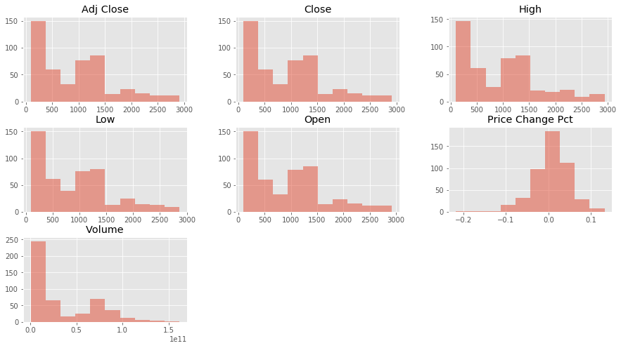

```python
# Measure Kurtosis and Skew.
# Plot histogram for each column.

matplotlib.style.use('ggplot')

df_index_SPY.hist(alpha=0.5, figsize=(15, 8))
```

From above histograms, we can see that, except price change percentage, all other 6 columns are obviously right skewed. Price change Percentage looks like Gaussian distribution，although not exactly centered around zero.

# Predictive Analysis

1. Time series studies in the close price of SPY500
2. Compare regression models for the transaction volume and the close price of SPY500.

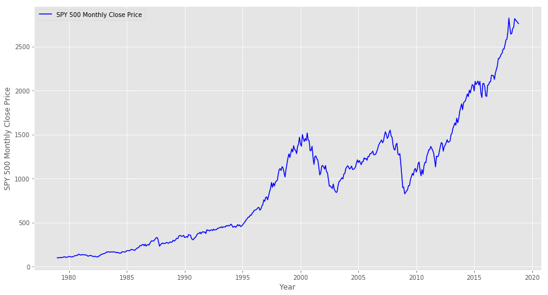

```python
#1. Time series studies in the close price of SPY500
# Have a close look of fluctation and irregularity SPY 500 monthly close price.
plt.figure(figsize=(15,8))
plt.plot(df_new_index_SPY.index, df_new_index_SPY.Close,'b',label='SPY 500 Monthly Close Price')

plt.xlabel(r"Year")
plt.ylabel(r"SPY 500 Monthly Close Price")
plt.legend(loc='upper left')
plt.show()
```

From above line chart, we can learn that, it looks like the components on the graph jumps in magnitude overtime, and the pattern of seasonal viation is not roughly stable over the years. Therefore, it might be better to choose multiplicative model instead of addictive model. And compared with ARMA, for this case, it looks like it might be better to choose ARIMA model(Autoregressive Interated Moving Average Model) , let's test the stationarity of the dataset first.

```python
# Test stationarity of the dataset
# Creat a new sub-set for time and close price of SPY 500 only
df_cp_SPY = pd.DataFrame(df_new_index_SPY['Close'])
df_cp_SPY.head()
```

| Date | Close |
| --- | --- |
| 1979-01-01 | 99.930000 |
| 1979-02-01 | 96.279999 |
| 1979-03-01 | 101.589996 |
| 1979-04-01 | 101.760002 |
| 1979-05-01 | 99.080002 |

```python
#we can split the time series into two contiguous sequences.
#We can then calculate the mean and variance of each group of numbers and compare the values.

X = df_cp_SPY['Close'].values
split = round(len(X) / 2)
X1, X2 = X[0:split], X[split:]
mean1, mean2 = X1.mean(), X2.mean()
var1, var2 = X1.var(), X2.var()
print('mean1=%f, mean2=%f' % (mean1, mean2))
print('variance1=%f, variance2=%f' % (var1, var2))
```

```
mean1=358.958462, mean2=1484.549528
variance1=61049.909513, variance2=222094.050799
```

We can clearly see that, the mean and variance values are very different. Now we know, the time series sub dataset of SPY 500 Close price is not stationary. To further test it, we can also try a hypothesis testing to verify it.

```python
#Augmented Dickey-Fuller test
#Null Hypothesis (H0): If failed to be rejected, it suggests the time series has a unit root, meaning it is non-stationary. It has some time dependent structure.
#Alternate Hypothesis (H1): The null hypothesis is rejected; it suggests the time series does not have a unit root, meaning it is stationary. It does not have time-dependent structure.
```

```python
from statsmodels.tsa.stattools import adfuller
result = adfuller(X)
print('ADF Statistic: %f' % result[0])
print('p-value: %f' % result[1])
print('Critical Values:')
for key, value in result[4].items():
	print('\t%s: %.3f' % (key, value))
```

```
ADF Statistic: 1.600418
p-value: 0.997859
Critical Values:
	1%: -3.444
	5%: -2.868
	10%: -2.570
```

```
                             ARIMA Model Results
==============================================================================
Dep. Variable:                D.Close   No. Observations:                  467
Model:                 ARIMA(5, 1, 0)   Log Likelihood               -2395.826
Method:                       css-mle   S.D. of innovations             40.904
Date:                Fri, 08 Jan 2021   AIC                           4805.652
Time:                        09:46:47   BIC                           4834.676
Sample:                             1   HQIC                          4817.074

=================================================================================
                    coef    std err          z      P>|z|      [0.025      0.975]
---------------------------------------------------------------------------------
const             5.7164      2.155      2.653      0.008       1.493       9.939
ar.L1.D.Close     0.0019      0.046      0.042      0.967      -0.088       0.092
ar.L2.D.Close    -0.0457      0.046     -0.989      0.323      -0.136       0.045
ar.L3.D.Close     0.0387      0.046      0.837      0.403      -0.052       0.129
ar.L4.D.Close     0.0157      0.046      0.339      0.735      -0.075       0.106
ar.L5.D.Close     0.1123      0.046      2.432      0.015       0.022       0.203
                                    Roots
=============================================================================
                  Real          Imaginary           Modulus         Frequency
-----------------------------------------------------------------------------
AR.1            1.5115           -0.0000j            1.5115           -0.0000
AR.2           -1.2337           -0.9707j            1.5698           -0.3939
AR.3           -1.2337           +0.9707j            1.5698            0.3939
AR.4            0.4082           -1.4911j            1.5460           -0.2075
AR.5            0.4082           +1.4911j            1.5460            0.2075
-----------------------------------------------------------------------------
```

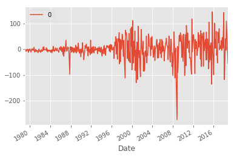

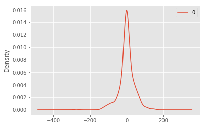

```
                0
count  467.000000
mean     0.007299
std     40.948152
min   -273.488723
25%    -11.845397
50%     -0.475628
75%     14.122300
max    145.055342
```

```python
from statsmodels.tsa.arima_model import ARIMA

def parser(x):
	return datetime.strptime('190'+x, '%Y-%m')

series1 = df_cp_SPY.Close
X2 = series1.values
# Print the summary of fit model
model = ARIMA(series1, order=(5,1,0))
model_fit = model.fit(disp=0)
print(model_fit.summary())
# plot residual errors

residuals = pd.DataFrame(model_fit.resid)
residuals.plot()
plt.show()
residuals.plot(kind='kde')
plt.show()
print(residuals.describe())
```

From above model analysis, we can learn that: 1) From the residual erros line chart, there's no very obvious trend, hence we can say this model did capture the trend of the dataset. 2) From the density plot of the residual error values, we can learn that the errors are Gaussian and they are centered on zero.And from the residuals'descriptive stastics, we can also learn that the mean value is 0.007299, which is very close to 0, hence we can say that there's merely no bias in the prediction.

```python
# Now let's use the fit model to calculate the predictive values and plot the prediction using ARIMA model.

from pandas import read_csv
from pandas import datetime
from statsmodels.tsa.arima_model import ARIMA
from sklearn.metrics import mean_squared_error

def parser(x):
	return datetime.strptime('190'+x, '%Y-%m')

series = df_new_index_SPY.Close
X = series.values
size = int(len(X) * 0.66)
train, test = X[0:size], X[size:len(X)]
history = [x for x in train]
predictions = list()
for t in range(len(test)):
	model = ARIMA(history, order=(5,1,0))
	model_fit = model.fit(disp=0)
	output = model_fit.forecast()
	yhat = output[0]
	predictions.append(yhat)
	obs = test[t]
	history.append(obs)
	print('predicted=%f, expected=%f' % (yhat, obs))
error = mean_squared_error(test, predictions)
print('Test MSE: %.3f' % error)
```

```
predicted=1188.006461, expected=1203.599976
predicted=1210.899104, expected=1180.589966
predicted=1189.830754, expected=1156.849976
predicted=1168.998963, expected=1191.500000
predicted=1187.607023, expected=1191.329956
predicted=1195.834057, expected=1234.180054
predicted=1233.187550, expected=1220.329956
predicted=1218.698114, expected=1228.810059
predicted=1239.168170, expected=1207.010010
predicted=1210.230126, expected=1249.479980
predicted=1257.779636, expected=1248.290039
predicted=1247.532314, expected=1280.079956
predicted=1284.123477, expected=1280.660034
predicted=1279.692824, expected=1294.869995
predicted=1304.626270, expected=1310.609985
predicted=1312.460178, expected=1270.089966
predicted=1280.852015, expected=1270.199951
predicted=1275.006310, expected=1276.660034
predicted=1280.379278, expected=1303.819946
predicted=1307.899624, expected=1335.849976
predicted=1330.682847, expected=1377.939941
predicted=1379.101377, expected=1400.630005
predicted=1403.747673, expected=1418.300049
predicted=1425.477524, expected=1438.239990
predicted=1445.601288, expected=1406.819946
predicted=1417.908821, expected=1420.859985
predicted=1427.875743, expected=1482.369995
predicted=1483.916672, expected=1530.619995
predicted=1534.497823, expected=1503.349976
predicted=1503.967992, expected=1455.270020
predicted=1464.596472, expected=1473.989990
predicted=1487.348911, expected=1526.750000
predicted=1534.472181, expected=1549.380005
predicted=1545.826886, expected=1481.140015
predicted=1479.284315, expected=1468.359985
predicted=1480.117242, expected=1378.550049
predicted=1394.265570, expected=1330.630005
predicted=1341.090314, expected=1322.699951
predicted=1314.856070, expected=1385.589966
predicted=1387.383438, expected=1400.380005
```

[output cut: 106 more lines]

```
predicted=2438.170083, expected=2470.300049
predicted=2475.774530, expected=2471.649902
predicted=2478.402784, expected=2519.360107
predicted=2529.454586, expected=2575.260010
predicted=2581.011367, expected=2584.840088
predicted=2596.089400, expected=2673.610107
predicted=2682.116478, expected=2823.810059
predicted=2837.550461, expected=2713.830078
predicted=2726.582683, expected=2640.870117
predicted=2661.176473, expected=2648.050049
predicted=2664.406544, expected=2705.270020
predicted=2722.834526, expected=2718.370117
predicted=2705.019987, expected=2816.290039
predicted=2816.403284, expected=2760.169922
Test MSE: 3314.363
```

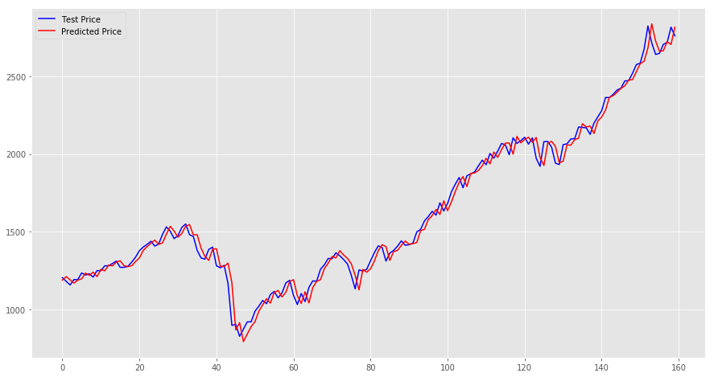

```python
# Plot the prediction, and see whether ARIMA model works well.
plt.figure(figsize=(15,8))
plt.plot(test,'b',label='Test Price')
plt.plot(predictions, color='red',label='Predicted Price')

plt.legend(loc='upper left')
plt.show()
```

From above chart, we can learn that ARIMA model works well for the time analysis and forecast S&P 500 close price.

Let's also make prediction on the close by the transaction value, and see which model works well.

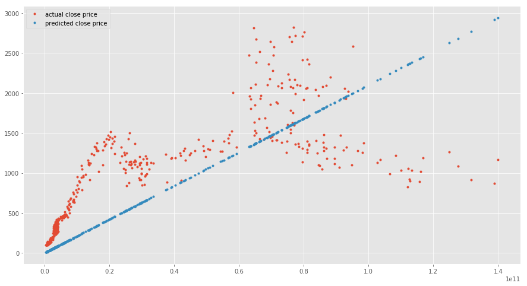

```python
# Use the linear regression model for predictive analyis on SPY 500 Close price.
from sklearn import linear_model
plt.figure(figsize=(15,8))
X = df_new_index_SPY[['Volume']]
y = df_new_index_SPY['Close'].values

model = linear_model.LinearRegression(fit_intercept=False)
res = model.fit(X, y)
plt.plot(X['Volume'], y, '.')
plt.plot(X['Volume'], model.predict(X), '.')
plt.legend(['actual close price', 'predicted close price'])
```

```python
# Using the random forest regression model for predictive analyis on SPY 500 Close price.
from sklearn import ensemble
ensemble_model = ensemble.RandomForestRegressor()
ensemble_model.fit(X,y)
```

```
RandomForestRegressor(bootstrap=True, criterion='mse', max_depth=None,
           max_features='auto', max_leaf_nodes=None,
           min_impurity_decrease=0.0, min_impurity_split=None,
           min_samples_leaf=1, min_samples_split=2,
           min_weight_fraction_leaf=0.0, n_estimators=10, n_jobs=None,
           oob_score=False, random_state=None, verbose=0, warm_start=False)
```

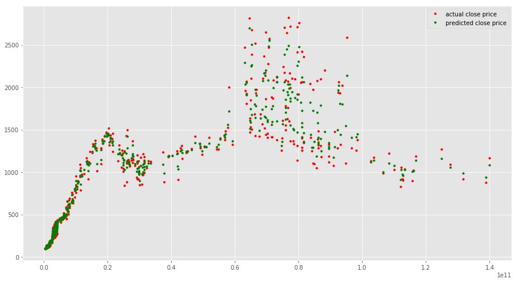

```python
plt.figure(figsize=(15,8))
plt.plot(X[['Volume']], y, 'r.')
plt.plot(X[['Volume']], ensemble_model.predict(X), 'g.')
plt.legend(['actual close price', 'predicted close price'])
```

Compared with the linear regression model and the random forest model, we can obviously see that, the random forest model works better for the S&P 500 dataset for the predictive analysis. So to predict the close price by the transaction volume, we'll use the random forest regression model.